# EDA - Amazon Kindle Books

Manoel Augusto Lima Oliveira de Almeida

2023-11-14

# 1 Contextualização

Conjunto de dados extraído de outubro de 2023. Contém detalhes do livro e informações de vendas, fonte de dados disponível em https://www.kaggle.com/datasets/asaniczka/amazon-kindle-books-dataset-2023-130k-books/ Acessado em: 07/11/2023.

O objetivo desta análise é realizar o EDA(Exploratory Data Analysis) do conjunto identificando os principais pontos a serem considerados para os dados.

# 2 Carregamento dos Pacotes

```r
library(ggplot2)
library(dplyr)
```

# 3 Leitura dos dados

Carregamento do arquivo CSV:

```r
dados <- read.csv("kindle_data-v2.csv", sep=",", na.strings = "")
```

O parâmentro `na.strings = ""` foi utilizado para tratamento dos valores ausentes do conjunto como `Na` para facilitar sua identificação.

Contagem total de linhas e colunas:

```r
dim(dados)
```

```
## [1] 133102     16
```

Nome das colunas:

```r
colnames(dados)
```

```
##  [1] "asin"              "title"             "author"
##  [4] "soldBy"            "imgUrl"            "productURL"
##  [7] "stars"             "reviews"           "price"
## [10] "isKindleUnlimited" "category_id"       "isBestSeller"
## [13] "isEditorsPick"     "isGoodReadsChoice" "publishedDate"
## [16] "category_name"
```

# 4 Identificação de dados ausentes

Utilizou-se o método `colSums` juntamente com os parâmetros `is.na` para identificar o total de dados ausentes por coluna.

```r
ausentes <- colSums(is.na(dados))
print(ausentes)
```

```
##              asin             title            author            soldBy
##                 0                 0               425              9233
##            imgUrl        productURL             stars           reviews
##                 0                 0                 0                 0
##             price isKindleUnlimited       category_id      isBestSeller
##                 0                 0                 0                 0
##     isEditorsPick isGoodReadsChoice     publishedDate     category_name
##                 0                 0             49016                 0
```

Devido a grande quantidade de dados ausentes optou-se por exluir a coluna “publishedDate”.

```r
dados <- dados[,-15]
```

As demais linhas com registros ausentes foram removidas:

```r
dados <- na.omit(dados)
dim(dados)
```

```
## [1] 123564     15
```

# 5 Tipagem dos dados

Identifica os tipos de dados de cada coluna e realiza a transformação de tipos das colunas

```r
# Transformação da coluna category_id em "character"
dados$category_id <- as.character(dados$category_id)
tipos_de_dados <- sapply(dados, class)

print(tipos_de_dados)
```

```
##              asin             title            author            soldBy
##       "character"       "character"       "character"       "character"
##            imgUrl        productURL             stars           reviews
##       "character"       "character"         "numeric"         "integer"
##             price isKindleUnlimited       category_id      isBestSeller
##         "numeric"       "character"       "character"       "character"
##     isEditorsPick isGoodReadsChoice     category_name
##       "character"       "character"       "character"
```

Separação do conjuntos em variáveis qualitativas (character ou factor) e quantitativas (numeric ou integer)

```r
dados_qualitativos <- dados[, tipos_de_dados %in% c("character", "factor")]
dados_quantitativos <- dados[, tipos_de_dados %in% c("numeric", "integer")]
```

# 6 Análise e visualização dos dados

Análise das principais variáveis identificadas no conjunto.

Resumo estatístico das variáveis quantitativas:

```r
summary(dados_quantitativos)
```

```
##      stars          reviews             price
##  Min.   :0.000   Min.   :     0.0   Min.   :  0.00
##  1st Qu.:4.400   1st Qu.:     0.0   1st Qu.:  5.95
##  Median :4.500   Median :    10.0   Median :  9.99
##  Mean   :4.395   Mean   :   867.7   Mean   : 15.79
##  3rd Qu.:4.700   3rd Qu.:   380.2   3rd Qu.: 14.99
##  Max.   :5.000   Max.   :618227.0   Max.   :682.00
```

Nota-se uma grande amplitude nos valores relacionados a coluna `reviews` e `price`

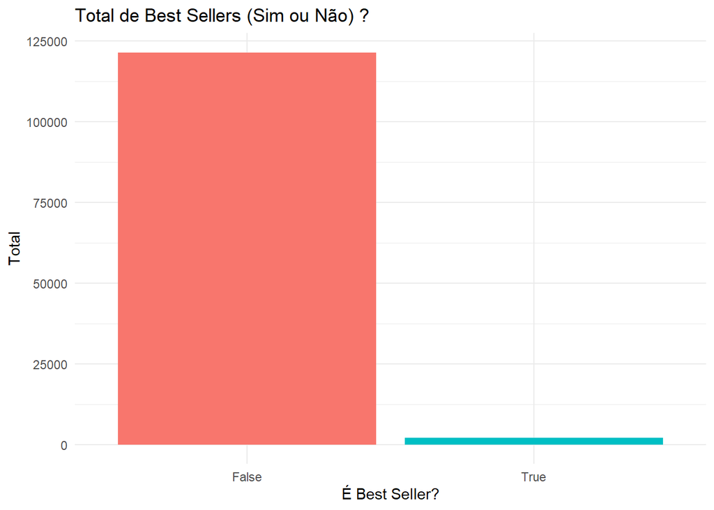

```r
isBestSeller <- ggplot(dados_qualitativos, aes(x = isBestSeller, fill = isBestSeller)) +
    geom_bar() +
    labs(title = "Total de Best Sellers (Sim ou Não) ?",
    x = "É Best Seller?",
    y = "Total") +
    theme_minimal() +
    theme(legend.position = "none")

isBestSeller
```